# BIOS 611 Project 1

Josh Zitovsky 730275298

09/24/2018

```r
#NOTE: Install the following packages before running this script: MASS, ggplot2, tidyverse, lmtest, nortest


#loading required packages to run this script
library(MASS)
library(ggplot2)
library(tidyverse)
library(lmtest)
library(nortest)
```

```r
#This data set gives crime statistics and urban proportions for every state in 1975.
#I wish to investigate whether states with greater Urban Populations had more murders (per capita) in 1975.
data(USArrests)
crime = as.tibble(USArrests)

#making the state a column/variable in the tibble (as opposed to just the row name)
crime = mutate(crime, state=rownames(crime))

#Getting the spearman's correlation between Murder and UrbanPop, as well as its associated p-value
test=cor.test(crime$Murder,crime$UrbanPop, method="spearman", exact=F)
corEstimate = round(test$estimate, 2)
corPValue = round(test$p.value, 2)
```

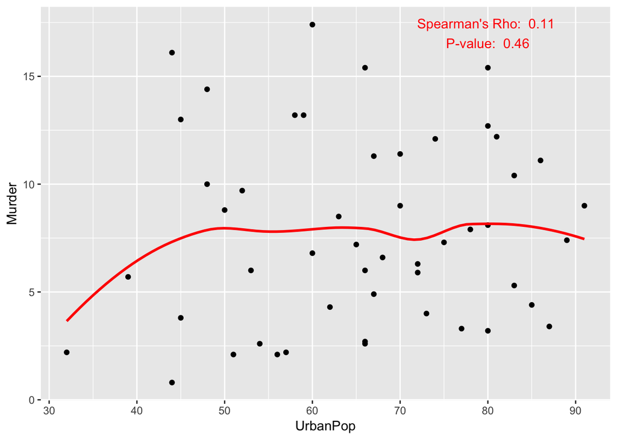

```r
#plotting a scatterplot of Murder vs. UrbanPop, with a data-fitted smoothed line and spearman's correlation information included
ggplot(data=crime, mapping=aes(y=Murder, x=UrbanPop)) +
  geom_point() +
  geom_smooth(se=F,color="red") +
  annotate('text', label=paste("Spearman's Rho: " , corEstimate, "\nP-value: ", corPValue), x=80,y=17, color="red")
```

```r
#Printing information for the states with the smallest UrbanProp values
crime %>%
  filter(rank(UrbanPop,ties.method="min")<=5) %>%
  select(Murder, UrbanPop, state) %>%
  arrange(UrbanPop)
```

```
## # A tibble: 6 x 3
##   Murder UrbanPop state
##    <dbl>    <int> <chr>
## 1    2.2       32 Vermont
## 2    5.7       39 West Virginia
## 3   16.1       44 Mississippi
## 4    0.8       44 North Dakota
## 5   13         45 North Carolina
## 6    3.8       45 South Dakota
```

```r
#Printing information for the states with the largest UrbanProp values
crime %>%
  filter(rank(desc(UrbanPop),ties.method="min")<=5) %>%
  select(Murder, UrbanPop, state) %>%
  arrange(desc(UrbanPop))
```

```
## # A tibble: 5 x 3
##   Murder UrbanPop state
##    <dbl>    <int> <chr>
## 1    9         91 California
## 2    7.4       89 New Jersey
## 3    3.4       87 Rhode Island
## 4   11.1       86 New York
## 5    4.4       85 Massachusetts
```

This figure was derived from the “USArrests” data set, which is derived from “World Almanac and Book of Facts 1975”. The data set contains murder, arrest, and rape arrests per 100,000 residents for each state in 1975, as well as the proportion of the population living in urban areas. As it is often said that higher crime rates are in urban areas, one would think there would be a relationship between state-wide murder rates and state-wide urban population proportions. However, it does not appear that that there is any relationship between state urban population proportion and state murder rate, as the scatterplot points show no clear pattern, the smoothed line remains mostly flat and a spearman’s correlation test gives a p-value of 0.46. The states with the highest urban population proportions are CA, NJ, RI, NY and MA, with murder rates varying from 3.4 (Rhode Island) to 11.1 (New York). The states with the lowest urban population proportions are VT, WV, MS, ND, NC and SD, with murder rates varying from 0.8 (North Dakota) to 16.1 (Mississippi).

As a next step, it would be interesting to look at the relationships between urban population proportions and other crimes (such as assault), as well as relationships between rates of different crimes. Looking at other data sets that collect crime rates for different years (particularly more recent years) would also be worthwhile.

(For non-statisticians) The points in the plot above plot UrbanPop and Murder values for each state. The red line illistrates the relationship, or trend, between Murder and UrbanPop. Spearman’s Rho is a measure of the association between the two variables, and the p-value is a way of determining whether the association is statistically significant (greater than what would occur by chance). A p-value < 0.05 is significant, and thus a p-value of 0.46 means that the association is not significant.

```r
#This data set gives finger length and height measurements for 3000 British criminals.
#I wish to investigate whether there is a relationship between finger length and body height
data(crimtab)
measure = as.tibble(crimtab) #this is a tibble of frequencies
#head(measure)

#turning the frequency table 'measure' into a tibble of numeric-type observations, with one observation per frequency
measure2 = tibble(Var1 = rep(measure$Var1, measure$n), Var2 = rep(measure$Var2, measure$n))
measure2 = mutate(measure2, fingerlength=as.numeric(Var1), height=as.numeric(Var2))
```

```r
#Printing slope estimates and p-values for a linear regression of height vs. fingerlength
line=lm(data=measure2, height~fingerlength)
summary(line)
```

```
##
## Call:
## lm(formula = height ~ fingerlength, data = measure2)
##
## Residuals:
##     Min      1Q  Median      3Q     Max
## -16.639  -3.163  -0.057   3.259  31.975
##
## Coefficients:
##              Estimate Std. Error t value Pr(>|t|)
## (Intercept)   76.6536     1.8874   40.61   <2e-16 ***
## fingerlength   7.7635     0.1633   47.55   <2e-16 ***
## ---
## Signif. codes:  0 '***' 0.001 '**' 0.01 '*' 0.05 '.' 0.1 ' ' 1
##
## Residual standard error: 4.906 on 2998 degrees of freedom
## Multiple R-squared:   0.43,  Adjusted R-squared:  0.4298
## F-statistic:  2261 on 1 and 2998 DF,  p-value: < 2.2e-16
```

```r
#The below code checks that the assumptions of linear regression are not violated
residuals=resid(line)
ad.test(residuals) #normality test for the residuals
```

```
##
##  Anderson-Darling normality test
##
## data:  residuals
## A = 0.6225, p-value = 0.105
```

```r
bptest(line) #equal variance test for the residuals
```

```
##
##  studentized Breusch-Pagan test
##
## data:  line
## BP = 0.003209, df = 1, p-value = 0.9548
```

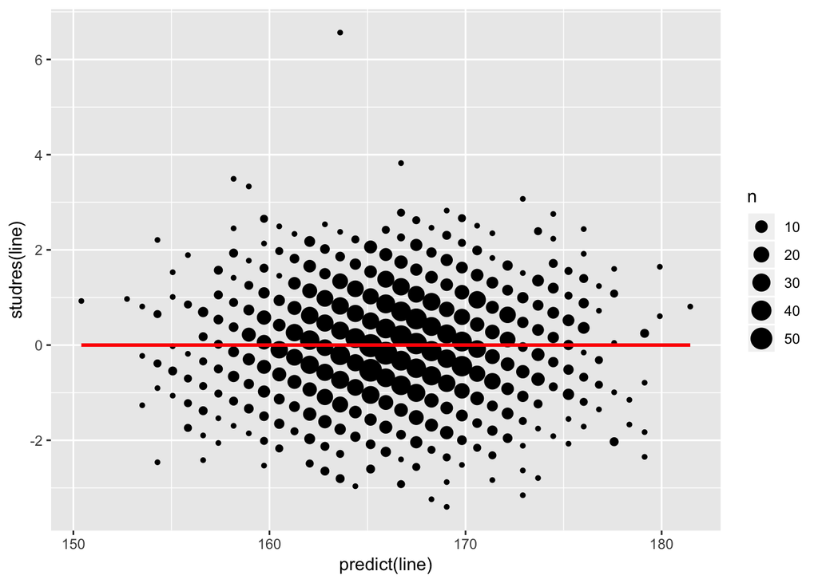

```r
#studentized residual plot to check linearity and other assumptions
ggplot(mapping=aes(y=studres(line), x=predict(line))) +
  geom_count() +
  geom_smooth(color="red")
```

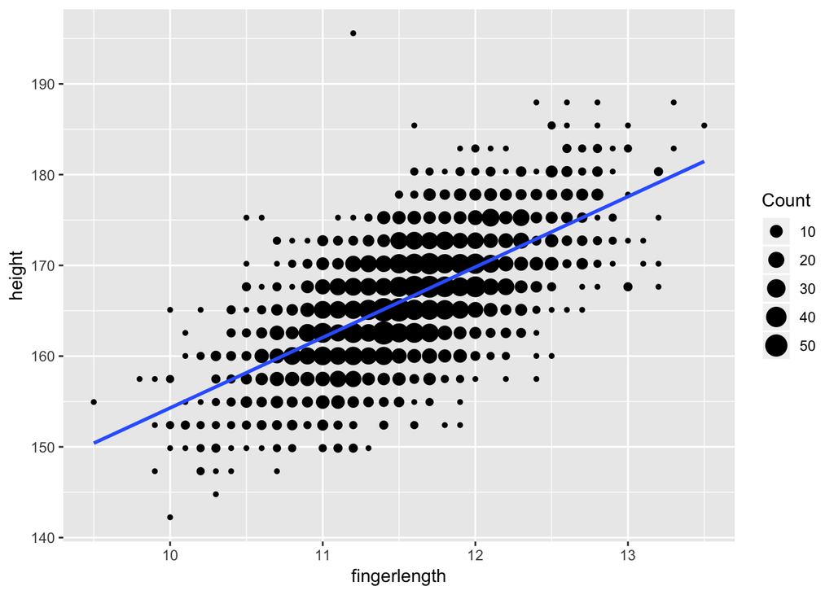

```r
#Graphing regression line over scatterplot of the data
ggplot(data=measure2, mapping=aes(y=height, x=fingerlength)) +
  geom_count() + #scatterplot with size aesthetic mapped to frequency
  geom_smooth(method="lm", se=F)  + #linear regression line
guides(size=guide_legend(title="Count")) #changing legend title to improve readability
```

This figure above derived from the “crimtab” data set. The data was first collected by the Central Metric Office in New Scotland Yard at some time near year 1900, and contains finger lengths and body heights for 3000 criminals from England and Wales. There was clearly a strong positive, linear relationship between an inmate’s finger length and their height, with finger length alone being able to predict 43% of the variation in height. On average, every increase in finger length was associated with a 7.8 increase in body height (in cm). All assumptions of linear regression were passed, supporting the validity of these estimations and inferences.

As a next step, it would be interesting to see with what accuracy finger length could predict height (in order words, what is the average prediction interval). It would also be interesting to investigate whether other parts of the body are better or worse at predicting height than finger length, such as foot size (though this would require additional data than is in “crimtab”).

```r
#This data set gives various demographic information of 437 midwestern conties.
#I wish to explore the univariate distribution of percentage below poverty among these counties.
data(midwest)
dem = as.tibble(midwest)

#finding the states included in the data set
unique(dem$state)
```

```
## [1] "IL" "IN" "MI" "OH" "WI"
```

```r
#ouputting summary statistics for percentage below poverty
summary(dem$percbelowpoverty)
```

```
##    Min. 1st Qu.  Median    Mean 3rd Qu.    Max.
##   2.180   9.199  11.822  12.511  15.133  48.691
```

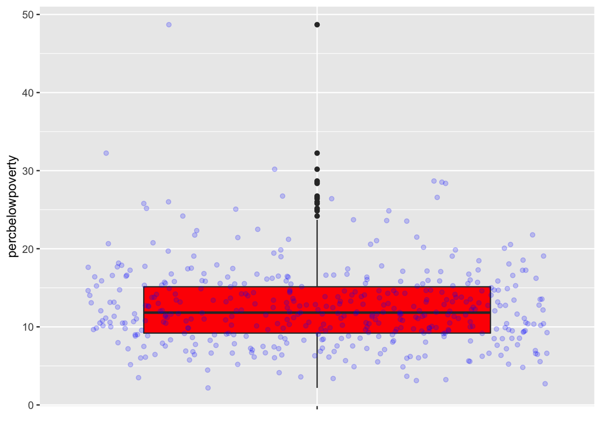

```r
#plotting boxplot of percentage below poverty, together with  points for all of the values
ggplot(data=dem, mapping=aes(x="", y=percbelowpoverty)) +
  geom_boxplot(fill="red") + #boxplot of variable
  geom_jitter(alpha=0.2, width=0.5, color="blue") +
  labs(x=NULL)
```

```r
#printing selected variables for counties with outlyingly large poverty levels (>q3+1.5*IQR)
dem %>%
  filter(percbelowpoverty>quantile(percbelowpoverty, .75)+1.5*IQR(percbelowpoverty)) %>%
  select(county, state, percbelowpoverty, percblack) %>%
  arrange(desc(percbelowpoverty))
```

```
## # A tibble: 15 x 4
##    county    state percbelowpoverty percblack
##    <chr>     <chr>            <dbl>     <dbl>
##  1 MENOMINEE WI                48.7     0
##  2 ALEXANDER IL                32.2    32.9
##  3 PULASKI   IL                30.2    32.8
##  4 ATHENS    OH                28.7     2.82
##  5 ADAMS     OH                28.5     0.185
##  6 JACKSON   IL                28.4    10.4
##  7 HARDIN    IL                26.7     1.64
##  8 PIKE      OH                26.6     1.35
##  9 LAKE      MI                26.4    13.4
## 10 MEIGS     OH                26.0     0.770
## 11 SCIOTO    OH                25.8     3.06
## 12 POPE      IL                25.2     6.08
## 13 MECOSTA   MI                25.1     2.62
## 14 ISABELLA  MI                24.9     1.16
## 15 JACKSON   OH                24.2     0.721
```

```r
#printing selected variables for counties with the smallest poverty levels
dem %>%
  filter(rank(percbelowpoverty,ties.method="min")<=15) %>%
  select(county, state, percbelowpoverty, percblack) %>%
  arrange(percbelowpoverty)
```

```
## # A tibble: 15 x 4
##    county     state percbelowpoverty percblack
##    <chr>      <chr>            <dbl>     <dbl>
##  1 OZAUKEE    WI                2.18    0.676
##  2 DU PAGE    IL                2.71    1.98
##  3 WAUKESHA   WI                3.12    0.360
##  4 WASHINGTON WI                3.24    0.131
##  5 KENDALL    IL                3.39    0.533
##  6 MCHENRY    IL                3.49    0.169
##  7 HAMILTON   IN                3.59    0.621
##  8 HENDRICKS  IN                3.67    0.905
##  9 LIVINGSTON MI                4.13    0.582
## 10 HANCOCK    IN                4.46    0.0966
## 11 MONROE     IL                4.81    0.0580
## 12 CALUMET    WI                4.87    0.0846
## 13 LAKE       OH                4.90    1.64
## 14 LAKE       IL                5.16    6.73
## 15 MACOMB     MI                5.19    1.45
```